# Risk Factor Analysis

## Outcome Variable

**Outcome Variable:** stunted

## Predictor Variables

**Intervention Variable:** earlybf

**Adjustment Set:**

- arm
- sex
- W_mage
- meducyrs
- feducyrs
- hhwealth_quart
- hfoodsec
- W_mhtcm
- vagbrth
- W_birthwt
- W_birthlen
- W_nrooms
- W_nchldlt5
- brthmon
- W_parity
- impfloor
- impsan
- safeh20
- delta_W_mage
- delta_meducyrs
- delta_feducyrs
- delta_hhwealth_quart
- delta_hfoodsec
- delta_W_mhtcm
- delta_vagbrth
- delta_W_birthwt
- delta_W_birthlen
- delta_W_nrooms
- delta_W_nchldlt5
- delta_brthmon
- delta_W_parity
- delta_impfloor
- delta_impsan
- delta_safeh20

## Stratifying Variables

The analysis was stratified on these variable(s):

- agecat
- studyid
- country

## Data Summary

| agecat | studyid | country | earlybf | stunted | n_cell | n |
| --- | --- | --- | --- | --- | --- | --- |
| Birth | ki0047075b-MAL-ED | BANGLADESH | 1 | 0 | 134 | 256 |
| Birth | ki0047075b-MAL-ED | BANGLADESH | 1 | 1 | 25 | 256 |
| Birth | ki0047075b-MAL-ED | BANGLADESH | 0 | 0 | 75 | 256 |
| Birth | ki0047075b-MAL-ED | BANGLADESH | 0 | 1 | 22 | 256 |
| Birth | ki0047075b-MAL-ED | BRAZIL | 1 | 0 | 76 | 191 |
| Birth | ki0047075b-MAL-ED | BRAZIL | 1 | 1 | 7 | 191 |
| Birth | ki0047075b-MAL-ED | BRAZIL | 0 | 0 | 94 | 191 |
| Birth | ki0047075b-MAL-ED | BRAZIL | 0 | 1 | 14 | 191 |
| Birth | ki0047075b-MAL-ED | INDIA | 1 | 0 | 106 | 205 |
| Birth | ki0047075b-MAL-ED | INDIA | 1 | 1 | 18 | 205 |
| Birth | ki0047075b-MAL-ED | INDIA | 0 | 0 | 66 | 205 |
| Birth | ki0047075b-MAL-ED | INDIA | 0 | 1 | 15 | 205 |
| Birth | ki0047075b-MAL-ED | NEPAL | 1 | 0 | 72 | 173 |
| Birth | ki0047075b-MAL-ED | NEPAL | 1 | 1 | 7 | 173 |
| Birth | ki0047075b-MAL-ED | NEPAL | 0 | 0 | 83 | 173 |
| Birth | ki0047075b-MAL-ED | NEPAL | 0 | 1 | 11 | 173 |
| Birth | ki0047075b-MAL-ED | PERU | 1 | 0 | 192 | 287 |
| Birth | ki0047075b-MAL-ED | PERU | 1 | 1 | 22 | 287 |
| Birth | ki0047075b-MAL-ED | PERU | 0 | 0 | 61 | 287 |
| Birth | ki0047075b-MAL-ED | PERU | 0 | 1 | 12 | 287 |
| Birth | ki0047075b-MAL-ED | SOUTH AFRICA | 1 | 0 | 143 | 247 |
| Birth | ki0047075b-MAL-ED | SOUTH AFRICA | 1 | 1 | 12 | 247 |
| Birth | ki0047075b-MAL-ED | SOUTH AFRICA | 0 | 0 | 78 | 247 |
| Birth | ki0047075b-MAL-ED | SOUTH AFRICA | 0 | 1 | 14 | 247 |
| Birth | ki0047075b-MAL-ED | TANZANIA, UNITED REPUBLIC OF | 1 | 0 | 96 | 123 |
| Birth | ki0047075b-MAL-ED | TANZANIA, UNITED REPUBLIC OF | 1 | 1 | 15 | 123 |
| Birth | ki0047075b-MAL-ED | TANZANIA, UNITED REPUBLIC OF | 0 | 0 | 9 | 123 |
| Birth | ki0047075b-MAL-ED | TANZANIA, UNITED REPUBLIC OF | 0 | 1 | 3 | 123 |
| Birth | ki1000109-EE | PAKISTAN | 1 | 0 | 0 | 2 |
| Birth | ki1000109-EE | PAKISTAN | 1 | 1 | 1 | 2 |

[output cut: 126 more lines]

The following strata were considered:

- agecat: 24 months, studyid: ki0047075b-MAL-ED, country: BANGLADESH
- agecat: 24 months, studyid: ki0047075b-MAL-ED, country: BRAZIL
- agecat: 24 months, studyid: ki0047075b-MAL-ED, country: INDIA
- agecat: 24 months, studyid: ki0047075b-MAL-ED, country: NEPAL
- agecat: 24 months, studyid: ki0047075b-MAL-ED, country: PERU
- agecat: 24 months, studyid: ki0047075b-MAL-ED, country: SOUTH AFRICA
- agecat: 24 months, studyid: ki0047075b-MAL-ED, country: TANZANIA, UNITED REPUBLIC OF
- agecat: 24 months, studyid: ki1017093c-NIH-Crypto, country: BANGLADESH
- agecat: 24 months, studyid: ki1113344-GMS-Nepal, country: NEPAL
- agecat: 24 months, studyid: ki1126311-ZVITAMBO, country: ZIMBABWE
- agecat: 24 months, studyid: kiGH5241-JiVitA-3, country: BANGLADESH
- agecat: 24 months, studyid: kiGH5241-JiVitA-4, country: BANGLADESH
- agecat: 6 months, studyid: ki0047075b-MAL-ED, country: BANGLADESH
- agecat: 6 months, studyid: ki0047075b-MAL-ED, country: BRAZIL
- agecat: 6 months, studyid: ki0047075b-MAL-ED, country: INDIA
- agecat: 6 months, studyid: ki0047075b-MAL-ED, country: NEPAL
- agecat: 6 months, studyid: ki0047075b-MAL-ED, country: PERU
- agecat: 6 months, studyid: ki0047075b-MAL-ED, country: SOUTH AFRICA
- agecat: 6 months, studyid: ki0047075b-MAL-ED, country: TANZANIA, UNITED REPUBLIC OF
- agecat: 6 months, studyid: ki1000109-EE, country: PAKISTAN
- agecat: 6 months, studyid: ki1000304b-SAS-CompFeed, country: INDIA
- agecat: 6 months, studyid: ki1017093c-NIH-Crypto, country: BANGLADESH
- agecat: 6 months, studyid: ki1113344-GMS-Nepal, country: NEPAL
- agecat: 6 months, studyid: ki1126311-ZVITAMBO, country: ZIMBABWE
- agecat: 6 months, studyid: kiGH5241-JiVitA-3, country: BANGLADESH
- agecat: 6 months, studyid: kiGH5241-JiVitA-4, country: BANGLADESH
- agecat: Birth, studyid: ki0047075b-MAL-ED, country: BANGLADESH
- agecat: Birth, studyid: ki0047075b-MAL-ED, country: BRAZIL
- agecat: Birth, studyid: ki0047075b-MAL-ED, country: INDIA
- agecat: Birth, studyid: ki0047075b-MAL-ED, country: NEPAL
- agecat: Birth, studyid: ki0047075b-MAL-ED, country: PERU
- agecat: Birth, studyid: ki0047075b-MAL-ED, country: SOUTH AFRICA
- agecat: Birth, studyid: ki0047075b-MAL-ED, country: TANZANIA, UNITED REPUBLIC OF
- agecat: Birth, studyid: ki1000109-EE, country: PAKISTAN
- agecat: Birth, studyid: ki1000304b-SAS-CompFeed, country: INDIA
- agecat: Birth, studyid: ki1017093c-NIH-Crypto, country: BANGLADESH
- agecat: Birth, studyid: ki1126311-ZVITAMBO, country: ZIMBABWE
- agecat: Birth, studyid: kiGH5241-JiVitA-3, country: BANGLADESH
- agecat: Birth, studyid: kiGH5241-JiVitA-4, country: BANGLADESH

### Dropped Strata

Some strata were dropped due to rare outcomes:

- agecat: Birth, studyid: ki0047075b-MAL-ED, country: TANZANIA, UNITED REPUBLIC OF
- agecat: Birth, studyid: ki1000109-EE, country: PAKISTAN
- agecat: Birth, studyid: ki1000304b-SAS-CompFeed, country: INDIA
- agecat: Birth, studyid: ki1017093c-NIH-Crypto, country: BANGLADESH
- agecat: 6 months, studyid: ki0047075b-MAL-ED, country: BRAZIL
- agecat: 6 months, studyid: ki0047075b-MAL-ED, country: NEPAL
- agecat: 24 months, studyid: ki0047075b-MAL-ED, country: BRAZIL
- agecat: 24 months, studyid: kiGH5241-JiVitA-3, country: BANGLADESH

## Methods Detail

We’re interested in the causal parameters $E[Y_a]$ for all values of $a \in \mathcal{A}$. These parameters represent the mean outcome if, possibly contrary to fact, we intervened to set all units to have $A=a$. Under the randomization and positivity assumptions, these are identified by the statistical parameters $\psi_a=E_W[E_{Y|A,W}(Y|A=a,W)]$. In addition, we’re interested in the mean of $Y$, $E[Y]$ under no intervention (the observed mean). We will estimate these parameters by using SuperLearner to fit the relevant likelihood factors – $E_{Y|A,W}(Y|A=a,W)$ and $p(A=a|W)$, and then updating our likelihood fit using a joint TMLE.

For unadjusted analyses ($W=\{\}$), initial likelihoods were estimated using Lrnr_glm to estimate the simple $E(Y|A)$ and Lrnr_mean to estimate $p(A)$. For adjusted analyses, a small library containing Lrnr_glmnet, Lrnr_xgboost, and Lrnr_mean was used.

Having estimated these parameters, we will then use the delta method to estimate relative risks and attributable risks relative to a prespecified baseline level of $A$.

# Results Detail

## Results Plots

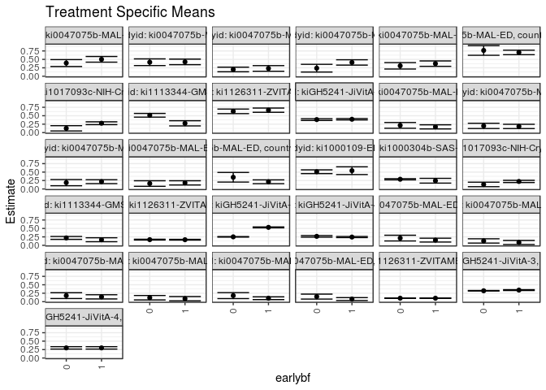

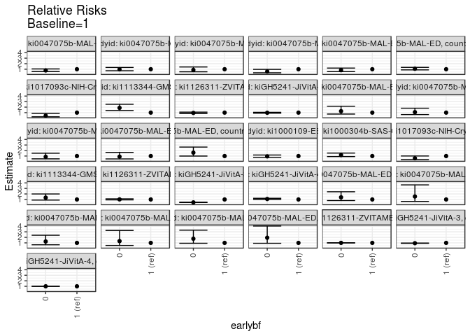

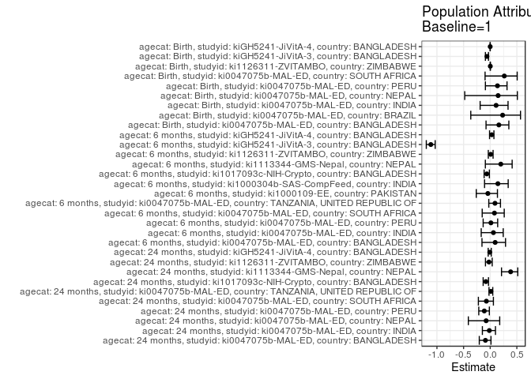

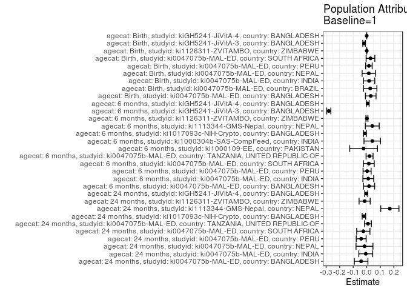

## Results Table

### Parameter: TSM

| agecat | studyid | country | intervention_level | baseline_level | estimate | ci_lower | ci_upper |
| --- | --- | --- | --- | --- | --- | --- | --- |
| Birth | ki0047075b-MAL-ED | BANGLADESH | 1 | NA | 0.1537485 | 0.0965281 | 0.2109690 |
| Birth | ki0047075b-MAL-ED | BANGLADESH | 0 | NA | 0.2137081 | 0.1293001 | 0.2981161 |
| Birth | ki0047075b-MAL-ED | BRAZIL | 1 | NA | 0.0843373 | 0.0243960 | 0.1442787 |
| Birth | ki0047075b-MAL-ED | BRAZIL | 0 | NA | 0.1296296 | 0.0661140 | 0.1931452 |
| Birth | ki0047075b-MAL-ED | INDIA | 1 | NA | 0.1431744 | 0.0808876 | 0.2054612 |
| Birth | ki0047075b-MAL-ED | INDIA | 0 | NA | 0.1793064 | 0.0932048 | 0.2654079 |
| Birth | ki0047075b-MAL-ED | NEPAL | 1 | NA | 0.0886076 | 0.0257610 | 0.1514542 |
| Birth | ki0047075b-MAL-ED | NEPAL | 0 | NA | 0.1170213 | 0.0518509 | 0.1821917 |
| Birth | ki0047075b-MAL-ED | PERU | 1 | NA | 0.1023361 | 0.0615485 | 0.1431238 |
| Birth | ki0047075b-MAL-ED | PERU | 0 | NA | 0.1793655 | 0.0913917 | 0.2673394 |
| Birth | ki0047075b-MAL-ED | SOUTH AFRICA | 1 | NA | 0.0774346 | 0.0348581 | 0.1200112 |
| Birth | ki0047075b-MAL-ED | SOUTH AFRICA | 0 | NA | 0.1499269 | 0.0761943 | 0.2236596 |
| Birth | ki1126311-ZVITAMBO | ZIMBABWE | 1 | NA | 0.1027441 | 0.0973797 | 0.1081085 |
| Birth | ki1126311-ZVITAMBO | ZIMBABWE | 0 | NA | 0.1030123 | 0.0976341 | 0.1083905 |
| Birth | kiGH5241-JiVitA-3 | BANGLADESH | 1 | NA | 0.3428744 | 0.3307108 | 0.3550381 |
| Birth | kiGH5241-JiVitA-3 | BANGLADESH | 0 | NA | 0.3231341 | 0.3154673 | 0.3308009 |
| Birth | kiGH5241-JiVitA-4 | BANGLADESH | 1 | NA | 0.3005627 | 0.2649984 | 0.3361271 |
| Birth | kiGH5241-JiVitA-4 | BANGLADESH | 0 | NA | 0.3003015 | 0.2646982 | 0.3359048 |
| 6 months | ki0047075b-MAL-ED | BANGLADESH | 1 | NA | 0.1700499 | 0.1089845 | 0.2311154 |
| 6 months | ki0047075b-MAL-ED | BANGLADESH | 0 | NA | 0.2148018 | 0.1297309 | 0.2998727 |
| 6 months | ki0047075b-MAL-ED | INDIA | 1 | NA | 0.1831910 | 0.1197997 | 0.2465823 |
| 6 months | ki0047075b-MAL-ED | INDIA | 0 | NA | 0.1988204 | 0.1209578 | 0.2766829 |
| 6 months | ki0047075b-MAL-ED | PERU | 1 | NA | 0.2168553 | 0.1593345 | 0.2743761 |
| 6 months | ki0047075b-MAL-ED | PERU | 0 | NA | 0.1871824 | 0.0948490 | 0.2795158 |
| 6 months | ki0047075b-MAL-ED | SOUTH AFRICA | 1 | NA | 0.1804488 | 0.1178270 | 0.2430706 |
| 6 months | ki0047075b-MAL-ED | SOUTH AFRICA | 0 | NA | 0.1605451 | 0.0782760 | 0.2428143 |
| 6 months | ki0047075b-MAL-ED | TANZANIA, UNITED REPUBLIC OF | 1 | NA | 0.2137970 | 0.1577123 | 0.2698817 |
| 6 months | ki0047075b-MAL-ED | TANZANIA, UNITED REPUBLIC OF | 0 | NA | 0.3460997 | 0.2033663 | 0.4888331 |
| 6 months | ki1000109-EE | PAKISTAN | 1 | NA | 0.5417857 | 0.4270082 | 0.6565633 |
| 6 months | ki1000109-EE | PAKISTAN | 0 | NA | 0.5103965 | 0.4551055 | 0.5656874 |
| 6 months | ki1000304b-SAS-CompFeed | INDIA | 1 | NA | 0.2434917 | 0.1728276 | 0.3141558 |
| 6 months | ki1000304b-SAS-CompFeed | INDIA | 0 | NA | 0.2873470 | 0.2702123 | 0.3044817 |
| 6 months | ki1017093c-NIH-Crypto | BANGLADESH | 1 | NA | 0.2231466 | 0.1903945 | 0.2558987 |
| 6 months | ki1017093c-NIH-Crypto | BANGLADESH | 0 | NA | 0.1339660 | 0.0671972 | 0.2007348 |
| 6 months | ki1113344-GMS-Nepal | NEPAL | 1 | NA | 0.1649416 | 0.1061677 | 0.2237154 |
| 6 months | ki1113344-GMS-Nepal | NEPAL | 0 | NA | 0.2194032 | 0.1765523 | 0.2622540 |
| 6 months | ki1126311-ZVITAMBO | ZIMBABWE | 1 | NA | 0.1657168 | 0.1544904 | 0.1769432 |
| 6 months | ki1126311-ZVITAMBO | ZIMBABWE | 0 | NA | 0.1679551 | 0.1557462 | 0.1801639 |
| 6 months | kiGH5241-JiVitA-3 | BANGLADESH | 1 | NA | 0.5316083 | 0.5181908 | 0.5450258 |
| 6 months | kiGH5241-JiVitA-3 | BANGLADESH | 0 | NA | 0.2507918 | 0.2424858 | 0.2590978 |
| 6 months | kiGH5241-JiVitA-4 | BANGLADESH | 1 | NA | 0.2450561 | 0.2279531 | 0.2621591 |
| 6 months | kiGH5241-JiVitA-4 | BANGLADESH | 0 | NA | 0.2654277 | 0.2412750 | 0.2895804 |
| 24 months | ki0047075b-MAL-ED | BANGLADESH | 1 | NA | 0.5009456 | 0.4169607 | 0.5849305 |
| 24 months | ki0047075b-MAL-ED | BANGLADESH | 0 | NA | 0.3905603 | 0.2882814 | 0.4928392 |
| 24 months | ki0047075b-MAL-ED | INDIA | 1 | NA | 0.4255008 | 0.3430079 | 0.5079937 |
| 24 months | ki0047075b-MAL-ED | INDIA | 0 | NA | 0.4155082 | 0.3166466 | 0.5143699 |
| 24 months | ki0047075b-MAL-ED | NEPAL | 1 | NA | 0.2313560 | 0.1477645 | 0.3149475 |
| 24 months | ki0047075b-MAL-ED | NEPAL | 0 | NA | 0.2008752 | 0.1328766 | 0.2688737 |
| 24 months | ki0047075b-MAL-ED | PERU | 1 | NA | 0.4090448 | 0.3298604 | 0.4882293 |
| 24 months | ki0047075b-MAL-ED | PERU | 0 | NA | 0.2387612 | 0.1245030 | 0.3530194 |
| 24 months | ki0047075b-MAL-ED | SOUTH AFRICA | 1 | NA | 0.3739605 | 0.2943671 | 0.4535538 |
| 24 months | ki0047075b-MAL-ED | SOUTH AFRICA | 0 | NA | 0.3093370 | 0.2138913 | 0.4047827 |
| 24 months | ki0047075b-MAL-ED | TANZANIA, UNITED REPUBLIC OF | 1 | NA | 0.7055556 | 0.6388140 | 0.7722971 |
| 24 months | ki0047075b-MAL-ED | TANZANIA, UNITED REPUBLIC OF | 0 | NA | 0.7647059 | 0.6217907 | 0.9076211 |
| 24 months | ki1017093c-NIH-Crypto | BANGLADESH | 1 | NA | 0.2776524 | 0.2359085 | 0.3193963 |
| 24 months | ki1017093c-NIH-Crypto | BANGLADESH | 0 | NA | 0.1267606 | 0.0492965 | 0.2042247 |
| 24 months | ki1113344-GMS-Nepal | NEPAL | 1 | NA | 0.2751165 | 0.1985787 | 0.3516542 |
| 24 months | ki1113344-GMS-Nepal | NEPAL | 0 | NA | 0.5130489 | 0.4579836 | 0.5681142 |
| 24 months | ki1126311-ZVITAMBO | ZIMBABWE | 1 | NA | 0.6645672 | 0.6019583 | 0.7271762 |
| 24 months | ki1126311-ZVITAMBO | ZIMBABWE | 0 | NA | 0.6299870 | 0.5629274 | 0.6970466 |
| 24 months | kiGH5241-JiVitA-4 | BANGLADESH | 1 | NA | 0.3956086 | 0.3747267 | 0.4164904 |
| 24 months | kiGH5241-JiVitA-4 | BANGLADESH | 0 | NA | 0.3856471 | 0.3593614 | 0.4119328 |

### Parameter: E(Y)

| agecat | studyid | country | intervention_level | baseline_level | estimate | ci_lower | ci_upper |
| --- | --- | --- | --- | --- | --- | --- | --- |
| Birth | ki0047075b-MAL-ED | BANGLADESH | NA | NA | 0.1835938 | 0.1360755 | 0.2311120 |
| Birth | ki0047075b-MAL-ED | BRAZIL | NA | NA | 0.1099476 | 0.0654669 | 0.1544284 |
| Birth | ki0047075b-MAL-ED | INDIA | NA | NA | 0.1609756 | 0.1105443 | 0.2114069 |
| Birth | ki0047075b-MAL-ED | NEPAL | NA | NA | 0.1040462 | 0.0584174 | 0.1496751 |
| Birth | ki0047075b-MAL-ED | PERU | NA | NA | 0.1184669 | 0.0810142 | 0.1559196 |
| Birth | ki0047075b-MAL-ED | SOUTH AFRICA | NA | NA | 0.1052632 | 0.0669131 | 0.1436132 |
| Birth | ki1126311-ZVITAMBO | ZIMBABWE | NA | NA | 0.1029304 | 0.0975643 | 0.1082966 |
| Birth | kiGH5241-JiVitA-3 | BANGLADESH | NA | NA | 0.3232690 | 0.3156091 | 0.3309289 |
| Birth | kiGH5241-JiVitA-4 | BANGLADESH | NA | NA | 0.3004866 | 0.2649179 | 0.3360553 |
| 6 months | ki0047075b-MAL-ED | BANGLADESH | NA | NA | 0.1875000 | 0.1380164 | 0.2369836 |
| 6 months | ki0047075b-MAL-ED | INDIA | NA | NA | 0.1949153 | 0.1442678 | 0.2455627 |
| 6 months | ki0047075b-MAL-ED | PERU | NA | NA | 0.2197802 | 0.1705687 | 0.2689917 |
| 6 months | ki0047075b-MAL-ED | SOUTH AFRICA | NA | NA | 0.1960000 | 0.1466935 | 0.2453065 |
| 6 months | ki0047075b-MAL-ED | TANZANIA, UNITED REPUBLIC OF | NA | NA | 0.2348178 | 0.1818480 | 0.2877876 |
| 6 months | ki1000109-EE | PAKISTAN | NA | NA | 0.5188172 | 0.4679751 | 0.5696593 |
| 6 months | ki1000304b-SAS-CompFeed | INDIA | NA | NA | 0.2844311 | 0.2666491 | 0.3022132 |
| 6 months | ki1017093c-NIH-Crypto | BANGLADESH | NA | NA | 0.2097902 | 0.1799252 | 0.2396552 |
| 6 months | ki1113344-GMS-Nepal | NEPAL | NA | NA | 0.2058824 | 0.1707553 | 0.2410094 |
| 6 months | ki1126311-ZVITAMBO | ZIMBABWE | NA | NA | 0.1674134 | 0.1588863 | 0.1759405 |
| 6 months | kiGH5241-JiVitA-3 | BANGLADESH | NA | NA | 0.2513830 | 0.2432594 | 0.2595066 |
| 6 months | kiGH5241-JiVitA-4 | BANGLADESH | NA | NA | 0.2525357 | 0.2384780 | 0.2665934 |
| 24 months | ki0047075b-MAL-ED | BANGLADESH | NA | NA | 0.4597156 | 0.3923103 | 0.5271210 |
| 24 months | ki0047075b-MAL-ED | INDIA | NA | NA | 0.4185022 | 0.3541865 | 0.4828179 |
| 24 months | ki0047075b-MAL-ED | NEPAL | NA | NA | 0.2149123 | 0.1614774 | 0.2683472 |
| 24 months | ki0047075b-MAL-ED | PERU | NA | NA | 0.3681592 | 0.3013164 | 0.4350020 |
| 24 months | ki0047075b-MAL-ED | SOUTH AFRICA | NA | NA | 0.3489362 | 0.2878666 | 0.4100058 |
| 24 months | ki0047075b-MAL-ED | TANZANIA, UNITED REPUBLIC OF | NA | NA | 0.7149533 | 0.6543278 | 0.7755787 |
| 24 months | ki1017093c-NIH-Crypto | BANGLADESH | NA | NA | 0.2568093 | 0.2190047 | 0.2946140 |
| 24 months | ki1113344-GMS-Nepal | NEPAL | NA | NA | 0.4461538 | 0.4004285 | 0.4918792 |
| 24 months | ki1126311-ZVITAMBO | ZIMBABWE | NA | NA | 0.6491228 | 0.6022363 | 0.6960093 |
| 24 months | kiGH5241-JiVitA-4 | BANGLADESH | NA | NA | 0.3922559 | 0.3752678 | 0.4092440 |

### Parameter: RR

| agecat | studyid | country | intervention_level | baseline_level | estimate | ci_lower | ci_upper |
| --- | --- | --- | --- | --- | --- | --- | --- |
| Birth | ki0047075b-MAL-ED | BANGLADESH | 1 | 1 | 1.0000000 | 1.0000000 | 1.0000000 |
| Birth | ki0047075b-MAL-ED | BANGLADESH | 0 | 1 | 1.3899847 | 0.8056606 | 2.3981037 |
| Birth | ki0047075b-MAL-ED | BRAZIL | 1 | 1 | 1.0000000 | 1.0000000 | 1.0000000 |
| Birth | ki0047075b-MAL-ED | BRAZIL | 0 | 1 | 1.5370370 | 0.6482982 | 3.6441300 |
| Birth | ki0047075b-MAL-ED | INDIA | 1 | 1 | 1.0000000 | 1.0000000 | 1.0000000 |
| Birth | ki0047075b-MAL-ED | INDIA | 0 | 1 | 1.2523630 | 0.6566143 | 2.3886369 |
| Birth | ki0047075b-MAL-ED | NEPAL | 1 | 1 | 1.0000000 | 1.0000000 | 1.0000000 |
| Birth | ki0047075b-MAL-ED | NEPAL | 0 | 1 | 1.3206687 | 0.5359877 | 3.2541155 |
| Birth | ki0047075b-MAL-ED | PERU | 1 | 1 | 1.0000000 | 1.0000000 | 1.0000000 |
| Birth | ki0047075b-MAL-ED | PERU | 0 | 1 | 1.7527093 | 0.9305585 | 3.3012323 |
| Birth | ki0047075b-MAL-ED | SOUTH AFRICA | 1 | 1 | 1.0000000 | 1.0000000 | 1.0000000 |
| Birth | ki0047075b-MAL-ED | SOUTH AFRICA | 0 | 1 | 1.9361736 | 0.9250607 | 4.0524566 |
| Birth | ki1126311-ZVITAMBO | ZIMBABWE | 1 | 1 | 1.0000000 | 1.0000000 | 1.0000000 |
| Birth | ki1126311-ZVITAMBO | ZIMBABWE | 0 | 1 | 1.0026100 | 0.9972849 | 1.0079635 |
| Birth | kiGH5241-JiVitA-3 | BANGLADESH | 1 | 1 | 1.0000000 | 1.0000000 | 1.0000000 |
| Birth | kiGH5241-JiVitA-3 | BANGLADESH | 0 | 1 | 0.9424269 | 0.9162612 | 0.9693398 |
| Birth | kiGH5241-JiVitA-4 | BANGLADESH | 1 | 1 | 1.0000000 | 1.0000000 | 1.0000000 |
| Birth | kiGH5241-JiVitA-4 | BANGLADESH | 0 | 1 | 0.9991309 | 0.9940272 | 1.0042608 |
| 6 months | ki0047075b-MAL-ED | BANGLADESH | 1 | 1 | 1.0000000 | 1.0000000 | 1.0000000 |
| 6 months | ki0047075b-MAL-ED | BANGLADESH | 0 | 1 | 1.2631691 | 0.7418823 | 2.1507404 |
| 6 months | ki0047075b-MAL-ED | INDIA | 1 | 1 | 1.0000000 | 1.0000000 | 1.0000000 |
| 6 months | ki0047075b-MAL-ED | INDIA | 0 | 1 | 1.0853174 | 0.6533249 | 1.8029526 |
| 6 months | ki0047075b-MAL-ED | PERU | 1 | 1 | 1.0000000 | 1.0000000 | 1.0000000 |
| 6 months | ki0047075b-MAL-ED | PERU | 0 | 1 | 0.8631674 | 0.4921373 | 1.5139230 |
| 6 months | ki0047075b-MAL-ED | SOUTH AFRICA | 1 | 1 | 1.0000000 | 1.0000000 | 1.0000000 |
| 6 months | ki0047075b-MAL-ED | SOUTH AFRICA | 0 | 1 | 0.8896990 | 0.4765442 | 1.6610511 |
| 6 months | ki0047075b-MAL-ED | TANZANIA, UNITED REPUBLIC OF | 1 | 1 | 1.0000000 | 1.0000000 | 1.0000000 |
| 6 months | ki0047075b-MAL-ED | TANZANIA, UNITED REPUBLIC OF | 0 | 1 | 1.6188239 | 0.9986658 | 2.6240920 |
| 6 months | ki1000109-EE | PAKISTAN | 1 | 1 | 1.0000000 | 1.0000000 | 1.0000000 |
| 6 months | ki1000109-EE | PAKISTAN | 0 | 1 | 0.9420633 | 0.7478745 | 1.1866742 |
| 6 months | ki1000304b-SAS-CompFeed | INDIA | 1 | 1 | 1.0000000 | 1.0000000 | 1.0000000 |
| 6 months | ki1000304b-SAS-CompFeed | INDIA | 0 | 1 | 1.1801101 | 0.9044645 | 1.5397617 |
| 6 months | ki1017093c-NIH-Crypto | BANGLADESH | 1 | 1 | 1.0000000 | 1.0000000 | 1.0000000 |
| 6 months | ki1017093c-NIH-Crypto | BANGLADESH | 0 | 1 | 0.6003499 | 0.3570133 | 1.0095420 |
| 6 months | ki1113344-GMS-Nepal | NEPAL | 1 | 1 | 1.0000000 | 1.0000000 | 1.0000000 |
| 6 months | ki1113344-GMS-Nepal | NEPAL | 0 | 1 | 1.3301873 | 0.8862206 | 1.9965663 |
| 6 months | ki1126311-ZVITAMBO | ZIMBABWE | 1 | 1 | 1.0000000 | 1.0000000 | 1.0000000 |
| 6 months | ki1126311-ZVITAMBO | ZIMBABWE | 0 | 1 | 1.0135066 | 0.9210060 | 1.1152975 |
| 6 months | kiGH5241-JiVitA-3 | BANGLADESH | 1 | 1 | 1.0000000 | 1.0000000 | 1.0000000 |
| 6 months | kiGH5241-JiVitA-3 | BANGLADESH | 0 | 1 | 0.4717605 | 0.4528668 | 0.4914425 |
| 6 months | kiGH5241-JiVitA-4 | BANGLADESH | 1 | 1 | 1.0000000 | 1.0000000 | 1.0000000 |
| 6 months | kiGH5241-JiVitA-4 | BANGLADESH | 0 | 1 | 1.0831305 | 0.9675493 | 1.2125187 |
| 24 months | ki0047075b-MAL-ED | BANGLADESH | 1 | 1 | 1.0000000 | 1.0000000 | 1.0000000 |
| 24 months | ki0047075b-MAL-ED | BANGLADESH | 0 | 1 | 0.7796461 | 0.5785481 | 1.0506440 |
| 24 months | ki0047075b-MAL-ED | INDIA | 1 | 1 | 1.0000000 | 1.0000000 | 1.0000000 |
| 24 months | ki0047075b-MAL-ED | INDIA | 0 | 1 | 0.9765157 | 0.7238824 | 1.3173176 |
| 24 months | ki0047075b-MAL-ED | NEPAL | 1 | 1 | 1.0000000 | 1.0000000 | 1.0000000 |
| 24 months | ki0047075b-MAL-ED | NEPAL | 0 | 1 | 0.8682515 | 0.5362153 | 1.4058916 |
| 24 months | ki0047075b-MAL-ED | PERU | 1 | 1 | 1.0000000 | 1.0000000 | 1.0000000 |
| 24 months | ki0047075b-MAL-ED | PERU | 0 | 1 | 0.5837042 | 0.3504648 | 0.9721677 |
| 24 months | ki0047075b-MAL-ED | SOUTH AFRICA | 1 | 1 | 1.0000000 | 1.0000000 | 1.0000000 |
| 24 months | ki0047075b-MAL-ED | SOUTH AFRICA | 0 | 1 | 0.8271917 | 0.5676431 | 1.2054160 |
| 24 months | ki0047075b-MAL-ED | TANZANIA, UNITED REPUBLIC OF | 1 | 1 | 1.0000000 | 1.0000000 | 1.0000000 |
| 24 months | ki0047075b-MAL-ED | TANZANIA, UNITED REPUBLIC OF | 0 | 1 | 1.0838351 | 0.8790097 | 1.3363886 |
| 24 months | ki1017093c-NIH-Crypto | BANGLADESH | 1 | 1 | 1.0000000 | 1.0000000 | 1.0000000 |
| 24 months | ki1017093c-NIH-Crypto | BANGLADESH | 0 | 1 | 0.4565441 | 0.2433150 | 0.8566365 |
| 24 months | ki1113344-GMS-Nepal | NEPAL | 1 | 1 | 1.0000000 | 1.0000000 | 1.0000000 |
| 24 months | ki1113344-GMS-Nepal | NEPAL | 0 | 1 | 1.8648426 | 1.3843424 | 2.5121227 |
| 24 months | ki1126311-ZVITAMBO | ZIMBABWE | 1 | 1 | 1.0000000 | 1.0000000 | 1.0000000 |
| 24 months | ki1126311-ZVITAMBO | ZIMBABWE | 0 | 1 | 0.9479658 | 0.8260883 | 1.0878245 |
| 24 months | kiGH5241-JiVitA-4 | BANGLADESH | 1 | 1 | 1.0000000 | 1.0000000 | 1.0000000 |
| 24 months | kiGH5241-JiVitA-4 | BANGLADESH | 0 | 1 | 0.9748199 | 0.8984482 | 1.0576835 |

### Parameter: PAR

| agecat | studyid | country | intervention_level | baseline_level | estimate | ci_lower | ci_upper |
| --- | --- | --- | --- | --- | --- | --- | --- |
| Birth | ki0047075b-MAL-ED | BANGLADESH | 1 | NA | 0.0298452 | -0.0093495 | 0.0690399 |
| Birth | ki0047075b-MAL-ED | BRAZIL | 1 | NA | 0.0256103 | -0.0238753 | 0.0750959 |
| Birth | ki0047075b-MAL-ED | INDIA | 1 | NA | 0.0178012 | -0.0239457 | 0.0595480 |
| Birth | ki0047075b-MAL-ED | NEPAL | 1 | NA | 0.0154386 | -0.0338001 | 0.0646774 |
| Birth | ki0047075b-MAL-ED | PERU | 1 | NA | 0.0161308 | -0.0080723 | 0.0403339 |
| Birth | ki0047075b-MAL-ED | SOUTH AFRICA | 1 | NA | 0.0278285 | -0.0043511 | 0.0600081 |
| Birth | ki1126311-ZVITAMBO | ZIMBABWE | 1 | NA | 0.0001863 | -0.0000977 | 0.0004704 |
| Birth | kiGH5241-JiVitA-3 | BANGLADESH | 1 | NA | -0.0196054 | -0.0290285 | -0.0101823 |
| Birth | kiGH5241-JiVitA-4 | BANGLADESH | 1 | NA | -0.0000761 | -0.0005429 | 0.0003906 |
| 6 months | ki0047075b-MAL-ED | BANGLADESH | 1 | NA | 0.0174501 | -0.0238267 | 0.0587268 |
| 6 months | ki0047075b-MAL-ED | INDIA | 1 | NA | 0.0117242 | -0.0282214 | 0.0516699 |
| 6 months | ki0047075b-MAL-ED | PERU | 1 | NA | 0.0029249 | -0.0269210 | 0.0327708 |
| 6 months | ki0047075b-MAL-ED | SOUTH AFRICA | 1 | NA | 0.0155512 | -0.0245795 | 0.0556819 |
| 6 months | ki0047075b-MAL-ED | TANZANIA, UNITED REPUBLIC OF | 1 | NA | 0.0210208 | -0.0048016 | 0.0468432 |
| 6 months | ki1000109-EE | PAKISTAN | 1 | NA | -0.0229685 | -0.1254712 | 0.0795341 |
| 6 months | ki1000304b-SAS-CompFeed | INDIA | 1 | NA | 0.0409394 | -0.0203150 | 0.1021939 |
| 6 months | ki1017093c-NIH-Crypto | BANGLADESH | 1 | NA | -0.0133564 | -0.0237817 | -0.0029310 |
| 6 months | ki1113344-GMS-Nepal | NEPAL | 1 | NA | 0.0409408 | -0.0103452 | 0.0922268 |
| 6 months | ki1126311-ZVITAMBO | ZIMBABWE | 1 | NA | 0.0016966 | -0.0058114 | 0.0092047 |
| 6 months | kiGH5241-JiVitA-3 | BANGLADESH | 1 | NA | -0.2802253 | -0.2953545 | -0.2650960 |
| 6 months | kiGH5241-JiVitA-4 | BANGLADESH | 1 | NA | 0.0074796 | -0.0028860 | 0.0178453 |
| 24 months | ki0047075b-MAL-ED | BANGLADESH | 1 | NA | -0.0412300 | -0.0912963 | 0.0088363 |
| 24 months | ki0047075b-MAL-ED | INDIA | 1 | NA | -0.0069986 | -0.0582654 | 0.0442683 |
| 24 months | ki0047075b-MAL-ED | NEPAL | 1 | NA | -0.0164437 | -0.0789613 | 0.0460738 |
| 24 months | ki0047075b-MAL-ED | PERU | 1 | NA | -0.0408856 | -0.0773650 | -0.0044063 |
| 24 months | ki0047075b-MAL-ED | SOUTH AFRICA | 1 | NA | -0.0250243 | -0.0739955 | 0.0239470 |
| 24 months | ki0047075b-MAL-ED | TANZANIA, UNITED REPUBLIC OF | 1 | NA | 0.0093977 | -0.0158301 | 0.0346255 |
| 24 months | ki1017093c-NIH-Crypto | BANGLADESH | 1 | NA | -0.0208430 | -0.0338062 | -0.0078799 |
| 24 months | ki1113344-GMS-Nepal | NEPAL | 1 | NA | 0.1710374 | 0.1037508 | 0.2383240 |
| 24 months | ki1126311-ZVITAMBO | ZIMBABWE | 1 | NA | -0.0154444 | -0.0564396 | 0.0255507 |
| 24 months | kiGH5241-JiVitA-4 | BANGLADESH | 1 | NA | -0.0033527 | -0.0147096 | 0.0080043 |

### Parameter: PAF

| agecat | studyid | country | intervention_level | baseline_level | estimate | ci_lower | ci_upper |
| --- | --- | --- | --- | --- | --- | --- | --- |
| Birth | ki0047075b-MAL-ED | BANGLADESH | 1 | NA | 0.1625611 | -0.0783677 | 0.3496616 |
| Birth | ki0047075b-MAL-ED | BRAZIL | 1 | NA | 0.2329317 | -0.3648710 | 0.5689016 |
| Birth | ki0047075b-MAL-ED | INDIA | 1 | NA | 0.1105831 | -0.1891402 | 0.3347610 |
| Birth | ki0047075b-MAL-ED | NEPAL | 1 | NA | 0.1483826 | -0.4782311 | 0.5093783 |
| Birth | ki0047075b-MAL-ED | PERU | 1 | NA | 0.1361625 | -0.0902714 | 0.3155693 |
| Birth | ki0047075b-MAL-ED | SOUTH AFRICA | 1 | NA | 0.2643709 | -0.0964221 | 0.5064399 |
| Birth | ki1126311-ZVITAMBO | ZIMBABWE | 1 | NA | 0.0018100 | -0.0009519 | 0.0045643 |
| Birth | kiGH5241-JiVitA-3 | BANGLADESH | 1 | NA | -0.0606473 | -0.0902323 | -0.0318651 |
| Birth | kiGH5241-JiVitA-4 | BANGLADESH | 1 | NA | -0.0002533 | -0.0018086 | 0.0012995 |
| 6 months | ki0047075b-MAL-ED | BANGLADESH | 1 | NA | 0.0930670 | -0.1545918 | 0.2876032 |
| 6 months | ki0047075b-MAL-ED | INDIA | 1 | NA | 0.0601505 | -0.1689058 | 0.2443214 |
| 6 months | ki0047075b-MAL-ED | PERU | 1 | NA | 0.0133084 | -0.1323123 | 0.1402015 |
| 6 months | ki0047075b-MAL-ED | SOUTH AFRICA | 1 | NA | 0.0793429 | -0.1504173 | 0.2632155 |
| 6 months | ki0047075b-MAL-ED | TANZANIA, UNITED REPUBLIC OF | 1 | NA | 0.0895197 | -0.0267308 | 0.1926079 |
| 6 months | ki1000109-EE | PAKISTAN | 1 | NA | -0.0442709 | -0.2617831 | 0.1357455 |
| 6 months | ki1000304b-SAS-CompFeed | INDIA | 1 | NA | 0.1439345 | -0.1060546 | 0.3374213 |
| 6 months | ki1017093c-NIH-Crypto | BANGLADESH | 1 | NA | -0.0636653 | -0.1143046 | -0.0153273 |
| 6 months | ki1113344-GMS-Nepal | NEPAL | 1 | NA | 0.1988552 | -0.0912044 | 0.4118123 |
| 6 months | ki1126311-ZVITAMBO | ZIMBABWE | 1 | NA | 0.0101345 | -0.0357347 | 0.0539723 |
| 6 months | kiGH5241-JiVitA-3 | BANGLADESH | 1 | NA | -1.1147342 | -1.1997403 | -1.0330131 |
| 6 months | kiGH5241-JiVitA-4 | BANGLADESH | 1 | NA | 0.0296181 | -0.0122691 | 0.0697720 |
| 24 months | ki0047075b-MAL-ED | BANGLADESH | 1 | NA | -0.0896858 | -0.2050884 | 0.0146656 |
| 24 months | ki0047075b-MAL-ED | INDIA | 1 | NA | -0.0167229 | -0.1469217 | 0.0986957 |
| 24 months | ki0047075b-MAL-ED | NEPAL | 1 | NA | -0.0765136 | -0.4104882 | 0.1783826 |
| 24 months | ki0047075b-MAL-ED | PERU | 1 | NA | -0.1110542 | -0.2148044 | -0.0161648 |
| 24 months | ki0047075b-MAL-ED | SOUTH AFRICA | 1 | NA | -0.0717159 | -0.2218077 | 0.0599380 |
| 24 months | ki0047075b-MAL-ED | TANZANIA, UNITED REPUBLIC OF | 1 | NA | 0.0131445 | -0.0228519 | 0.0478741 |
| 24 months | ki1017093c-NIH-Crypto | BANGLADESH | 1 | NA | -0.0811615 | -0.1324602 | -0.0321865 |
| 24 months | ki1113344-GMS-Nepal | NEPAL | 1 | NA | 0.3833597 | 0.2121657 | 0.5173537 |
| 24 months | ki1126311-ZVITAMBO | ZIMBABWE | 1 | NA | -0.0237928 | -0.0889414 | 0.0374582 |
| 24 months | kiGH5241-JiVitA-4 | BANGLADESH | 1 | NA | -0.0085472 | -0.0379039 | 0.0199792 |